# The Lingering Traces of Racism Within Our Prison System

Lapi Kerr

2022-11-01

## Abstract

This report takes a dataset of incarceration trends from the [Vera Institute](https://www.vera.org/) and identifies the unequal distribution of Black males within multiple contexts of the US Prison System.

## Introduction

This report aims to present the massive disparities between incarcerated populations within the US prison system. Within the dataset used for this report, a set sourced from the Vera Institute, a list of values relating to specific gender/racial makeup of the US prison system are provided in a very bare-bones data format; as a data feminist, I took the data given and was able to extract not only some massive pointers to an overarching system of inequality within the prison system but was able to plot out some relationships between variables that show this system and other equally impactful problems in full effect.  
This dataset is for those affected by these systems, the direct stakeholders. Others who can act upon the information within the dataset are data scientists, those who can understand the ideas and act to prevent their continued effects on our society, politicians especially, and anyone who wishes to understand the hard data as to why America isn’t truly the “melting pot” it claims to be. The focus of the data is understanding and action on the systems of inequality; with data like this, we can begin to understand and work to fix the problems within the greater systems surrounding things like the prison and ICE systems.  
The main questions I answer in my report are that of the black male population in our prison system, asking where the highest population of incarcerated black males are as well as comparing the prison population versus white males. The answers to these questions are unfortunately not shocking, but are still undeniably scary regardless.

## Data Summary

The main values I calculated related to the population of Black males in US prisons. I first wrote a function to determine the total population of every race listed that were incarcerated in individual states, and tested it out on a variety of states; I got, for California (the highest populated state),

```
## [1] 807817.6
```

for the population of White incarcerated individuals, whereas I got

```
## [1] 596971.7
```

for the population of Black incarcerated individuals.  
This doesn’t seem to be a problem; the black population is indeed lower than the white population. However, if we compare this to the overall population of California, we begin to see problems. The population of White individuals from 15 to 64 years old in California is

```
## [1] 9897897
```

whereas the population of Black individuals of the same age range is

```
## [1] 1691505
```

That’s a considerable difference. This single example shows an overarching trend in this report, from coast to coast, of the over-representation of Black Americans in the US prison system.

## Growth of the US Prison Population

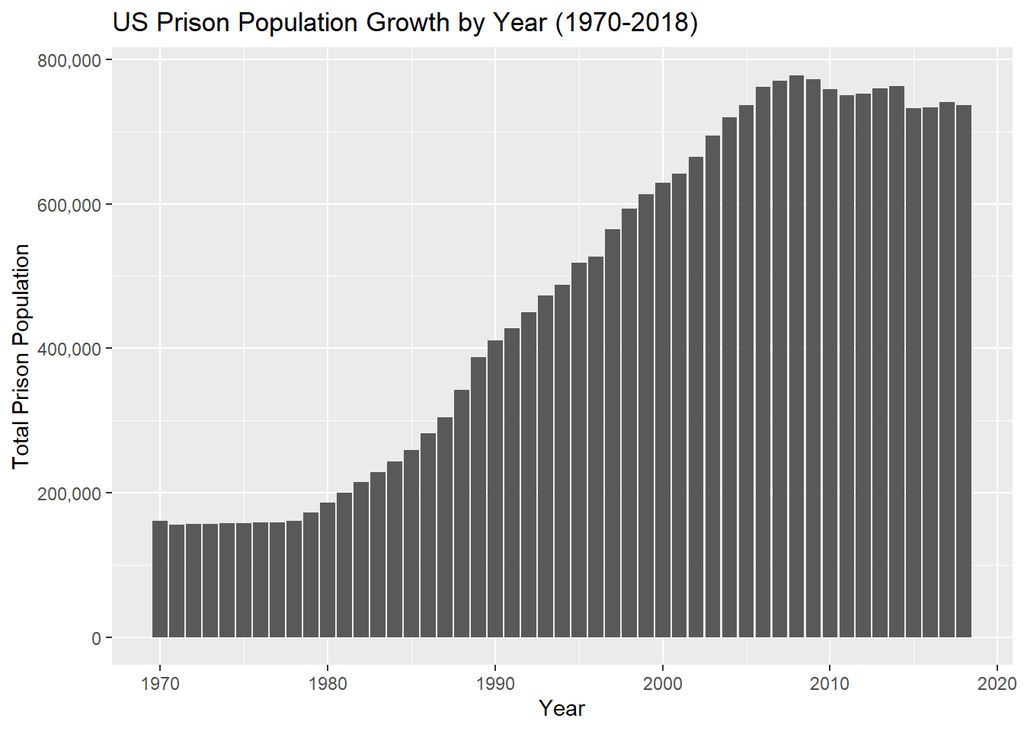

*Bar Graph showing the growth of the US Prison Population from 1970 - 2018.*

This bar graph shows the growth of the US Prison Population over a period of almost 50 years, from 1970 to 2018. It seems that the prison population stayed stagnant from 1970 to 1980, started rising rapidly until somewhere in the mid 2000’s, and slightly dipped at that point and again in the mid 2010’s.

## Growth of Prison Population by State

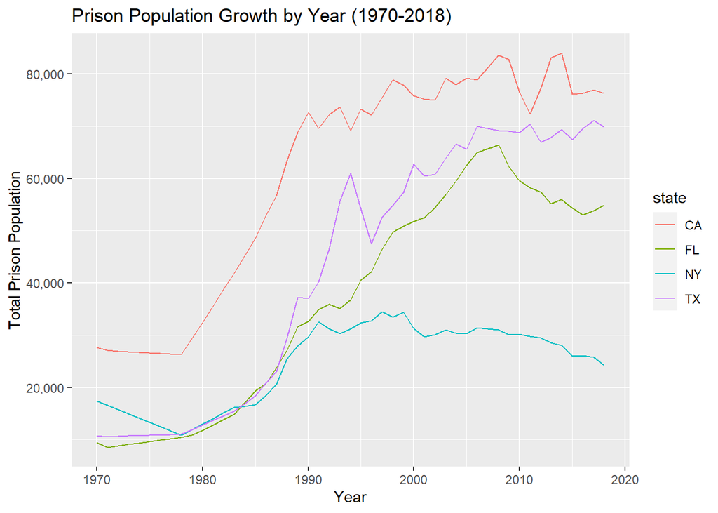

*Line chart showing the growth of New York, California, Florida and Texas’s prison populations from 1970 - 2018.*

## Comparing The Black Male Prison Population vs White Male Prison Population, By Year

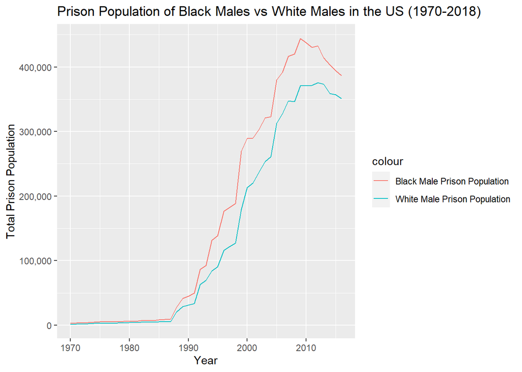

*Line chart showing the difference between the prison population of Black male individuals compared to the prison population of White male individuals.*

The question I wanted to ask with this chart was what exactly the difference was between the national Black male population of prisons when compared to their White counterparts, and it was, upsettingly, a very large margin of difference between the two determinants. While still remaining a lower percentage of the population than white individuals, Black Americans still face an incredible threat of incarceration compared to White Americans.  
You can see that, even from the start of the dataset, more Black Americans were incarcerated than White; this trend doesn’t change, hasn’t changed, and will not change as long as Black Americans are still marginalized, disenfranchised, and targeted by our penal system. There’s a sharp decrease in the Black prison population around 2010 and in both male prison populations around the early 2010’s, but the chart still speaks for itself.

## Showing The Rates Of Black American Incarceration Across The Continental U.S.

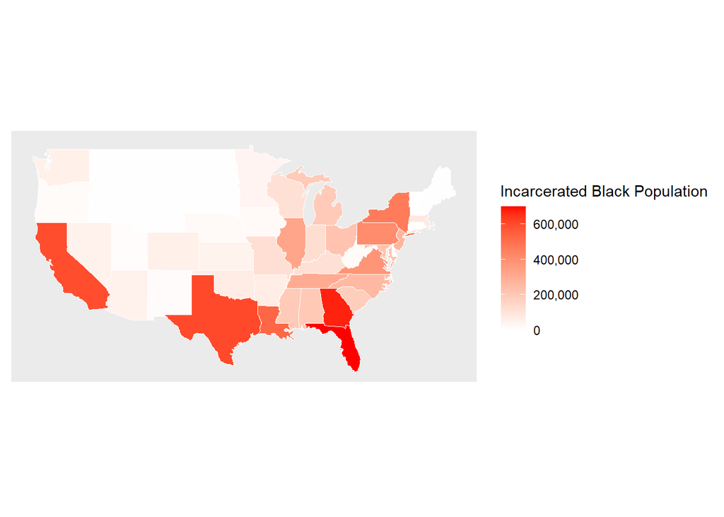

*Map showing what states have the highest number of incarcerated Black individuals.*

From this map, I specifically wanted to know “What states have the highest populations of incarcerated Black individuals?” and I ended up identifying something that I feel is important to understanding the trends within this visualization; while we can understand why California, New York, Texas, Florida and Pennsylvania may have higher populations of incarcerated individuals as a result of higher populations (being the 5 most populous states), I believe that the trend we begin to see after those states are discounted is one that is based in Southern states where racism still hides underneath the veneer of Confederate Flags and voting as red as the states here show up as.  
If you look at the area from Virginia to Georgia to Louisiana, you can see a full area where Black incarceration reaches 100,000 in almost every state. This area directly relates to the areas that separated from the Union in the Civil War, and who culturally even to this day are known for being states that have problems with racism and bigotry.